# Part I - (Prosper Loan Data Exploration)

## Introduction

This report delves into an extensive dataset comprising 113,937 loan records, encompassing essential information such as loan amount, borrower rate (interest rate), current loan status, borrower income, and various other attributes.

## Preliminary Wrangling

```python
# import all packages and set plots to be embedded inline
import numpy as np
import pandas as pd
import matplotlib.pyplot as plt
import seaborn as sb

%matplotlib inline

# suppress warnings
import warnings
warnings.simplefilter("ignore")
```

```python
prosper_loan = pd.read_csv('prosperLoanData.csv')
print(prosper_loan.shape[0])
prosper_loan.head()
```

```
113937
```

|  | ListingKey | ListingNumber | ListingCreationDate | CreditGrade | Term | LoanStatus | ClosedDate | BorrowerAPR | BorrowerRate | LenderYield | ... | LP_ServiceFees | LP_CollectionFees | LP_GrossPrincipalLoss | LP_NetPrincipalLoss | LP_NonPrincipalRecoverypayments | PercentFunded | Recommendations | InvestmentFromFriendsCount | InvestmentFromFriendsAmount | Investors |
| --- | --- | --- | --- | --- | --- | --- | --- | --- | --- | --- | --- | --- | --- | --- | --- | --- | --- | --- | --- | --- | --- |
| 0 | 1021339766868145413AB3B | 193129 | 2007-08-26 19:09:29.263000000 | C | 36 | Completed | 2009-08-14 00:00:00 | 0.16516 | 0.1580 | 0.1380 | ... | -133.18 | 0.0 | 0.0 | 0.0 | 0.0 | 1.0 | 0 | 0 | 0.0 | 258 |
| 1 | 10273602499503308B223C1 | 1209647 | 2014-02-27 08:28:07.900000000 | NaN | 36 | Current | NaN | 0.12016 | 0.0920 | 0.0820 | ... | 0.00 | 0.0 | 0.0 | 0.0 | 0.0 | 1.0 | 0 | 0 | 0.0 | 1 |
| 2 | 0EE9337825851032864889A | 81716 | 2007-01-05 15:00:47.090000000 | HR | 36 | Completed | 2009-12-17 00:00:00 | 0.28269 | 0.2750 | 0.2400 | ... | -24.20 | 0.0 | 0.0 | 0.0 | 0.0 | 1.0 | 0 | 0 | 0.0 | 41 |
| 3 | 0EF5356002482715299901A | 658116 | 2012-10-22 11:02:35.010000000 | NaN | 36 | Current | NaN | 0.12528 | 0.0974 | 0.0874 | ... | -108.01 | 0.0 | 0.0 | 0.0 | 0.0 | 1.0 | 0 | 0 | 0.0 | 158 |
| 4 | 0F023589499656230C5E3E2 | 909464 | 2013-09-14 18:38:39.097000000 | NaN | 36 | Current | NaN | 0.24614 | 0.2085 | 0.1985 | ... | -60.27 | 0.0 | 0.0 | 0.0 | 0.0 | 1.0 | 0 | 0 | 0.0 | 20 |

5 rows × 81 columns

```python
prosper_loan.LoanStatus.value_counts()
```

```
LoanStatus
Current                   56576
Completed                 38074
Chargedoff                11992
Defaulted                  5018
Past Due (1-15 days)        806
Past Due (31-60 days)       363
Past Due (61-90 days)       313
Past Due (91-120 days)      304
Past Due (16-30 days)       265
FinalPaymentInProgress      205
Past Due (>120 days)         16
Cancelled                     5
Name: count, dtype: int64
```

```python
prosper_loan.info()
```

```
<class 'pandas.core.frame.DataFrame'>
RangeIndex: 113937 entries, 0 to 113936
Data columns (total 81 columns):
 #   Column                               Non-Null Count   Dtype
---  ------                               --------------   -----
 0   ListingKey                           113937 non-null  object
 1   ListingNumber                        113937 non-null  int64
 2   ListingCreationDate                  113937 non-null  object
 3   CreditGrade                          28953 non-null   object
 4   Term                                 113937 non-null  int64
 5   LoanStatus                           113937 non-null  object
 6   ClosedDate                           55089 non-null   object
 7   BorrowerAPR                          113912 non-null  float64
 8   BorrowerRate                         113937 non-null  float64
 9   LenderYield                          113937 non-null  float64
```

[output cut: 73 more lines]

### What is the structure of your dataset?

The dataset contains 113,937 loan records and comprises 81 variables.

### What is/are the main feature(s) of interest in your dataset?

The primary focus of interest in this dataset is determining the features that play a significant role in predicting the LoanStatus. Specifically, the investigation aims to identify features related to whether a loan will be defaulted, completed, or charged off.

### What features in the dataset do you think will help support your investigation into your feature(s) of interest?

The features that are expected to be most crucial in predicting LoanStatus are EmploymentStatus and IncomeVerifiable. Additionally, other features like ListingCategory, CreditScoreRangeLower, CreditScoreRangeUpper, IsBorrowerHomeowner, CurrentlyInGroup, Recommendations, InvestmentFromFriendsCount, and LP_CustomerPrincipalPayments (Cummulative Principal Payments made on the loan before being charged off) are also anticipated to contribute to predicting LoanStatus, although to a lesser extent.

## Univariate Exploration

In this section of the report, the main focus of investigation will be on the variable 'LoanStatus' and its correlation with other features that are expected to play a significant role in predicting the outcome. As mentioned earlier, the features of particular interest include EmploymentStatus and IncomeVerifiable, along with several other variables such as ListingCategory, CreditScoreRangeLower, CreditScoreRangeUpper, IsBorrowerHomeowner, CurrentlyInGroup, Recommendations, InvestmentFromFriendsCount, and LP_CustomerPrincipalPayments (Cummulative Principal Payments made on the loan before being charged off). These selected features will be thoroughly examined to understand their influence on the 'LoanStatus' outcome, with the aim of gaining valuable insights into the factors that determine whether a loan is defaulted, completed, or charged off.

#### LoanStatus

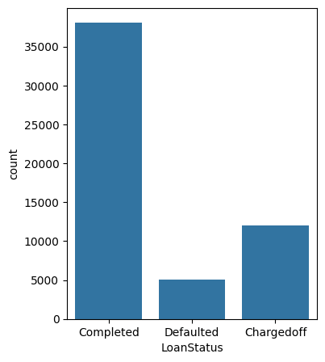

```python
prosper_loan_sub = prosper_loan.query('LoanStatus in ["Defaulted", "Completed", "Chargedoff"]')
plt.figure(figsize=(4, 5));
b_color=sb.color_palette()[0]
sb.countplot(x='LoanStatus', data=prosper_loan_sub, color=b_color);
```

#### EmploymentStatus

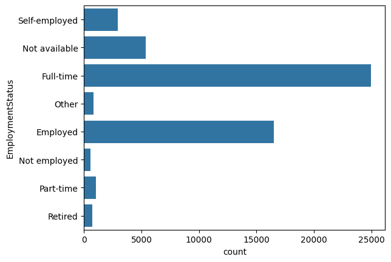

```python
sb.countplot(y='EmploymentStatus', data =prosper_loan_sub, color= b_color);
```

The majority of loan recipients are employed.

#### IncomeVerifiable

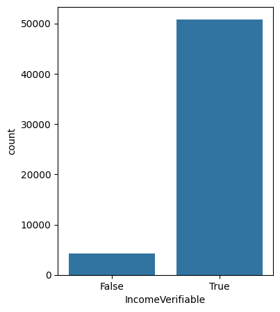

```python
plt.figure(figsize=(4, 5))
sb.countplot(x='IncomeVerifiable', data=prosper_loan_sub, color=b_color);
```

The majority of individuals who have been granted loans possess verifiable income sources.

#### Listing Category

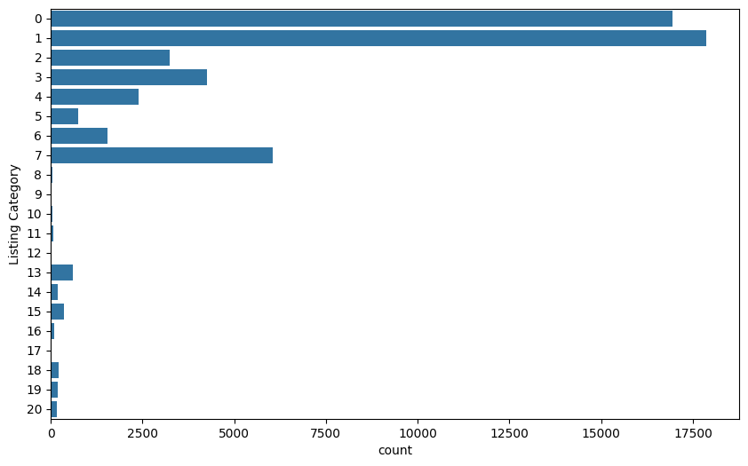

```python
plt.figure(figsize=(10, 6))
sb.countplot(y='ListingCategory (numeric)', data=prosper_loan_sub, color=b_color)
plt.ylabel('Listing Category');
```

```python
# Change the ylabel values by the appropriate values obtained from the documentation
categories = ['Not Available', 'Debt Consolidation', 'Home Improvement', 'Business', 'Personal Loan', 'Student Use', 'Auto', 'Other',
          'Baby&Adoption', 'Boat', 'Cosmetic Procedure', 'Engagement Ring', 'Green Loans', 'Household Expenses', 'Large Purchases',
          'Medical/Dental', 'Motorcycle', 'RV', 'Taxes', 'Vacation', 'Wedding Loans']
prosper_loan_sub['ListingCategory (numeric)'] = prosper_loan_sub['ListingCategory (numeric)'].apply(lambda i : categories[i])
prosper_loan_sub.rename(columns={'ListingCategory (numeric)':'ListingCategory'}, inplace=True)
prosper_loan_sub['ListingCategory'].dtype
```

```
dtype('O')
```

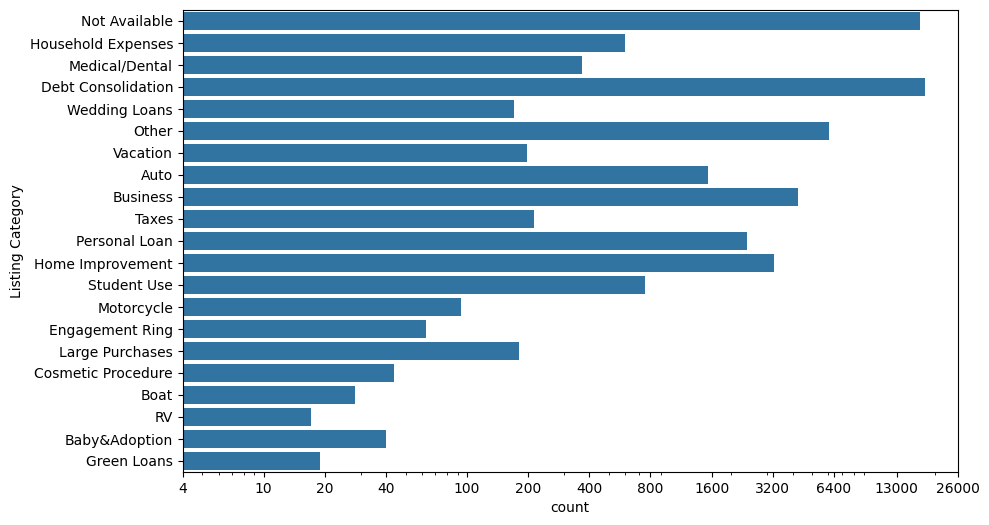

```python
# Plotting with renamed category values and transformed x-values
xticks =[4, 10, 20, 40, 100, 200, 400, 800, 1600, 3200, 6400, 13000, 26000]

plt.figure(figsize=(10, 6))
sb.countplot(y='ListingCategory', data=prosper_loan_sub, color=b_color)
plt.ylabel('Listing Category');
plt.xscale('log')
plt.xticks(xticks, xticks);
```

When visualized on a normal scale, the Listing Category exhibits numerous values with low counts, making them difficult to discern. However, when plotted on a logarithmic scale, these variations become more apparent. Among the categories, 'Debt Consolidation' emerges as the most frequent choice, while a significant number of individuals opt not to specify any category ('Not available') or select the 'Other' category.

#### CreditScoreRangeLower and CreditScoreRangeUpper

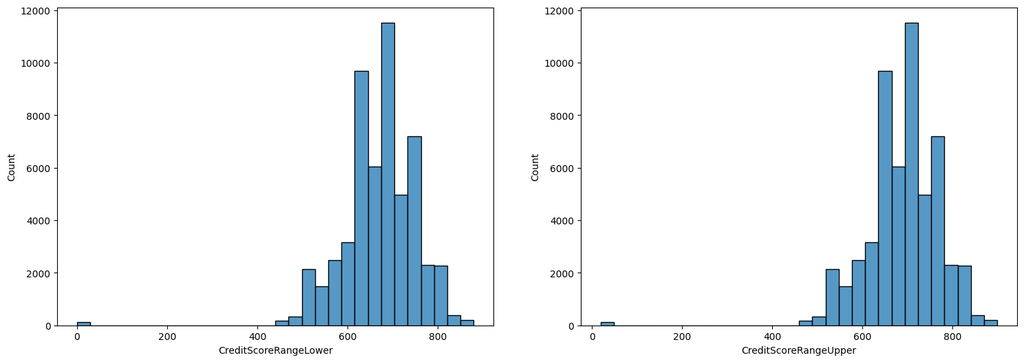

```python
# Distribution for credit score range lower and upper limit
plt.figure(figsize = [18, 6])

plt.subplot(1, 2, 1)
sb.histplot(x='CreditScoreRangeLower', data=prosper_loan_sub, bins=30, kde=False, color=b_color)
plt.subplot(1, 2, 2)
sb.histplot(x='CreditScoreRangeUpper', data=prosper_loan_sub, bins=30, kde=False, color=b_color);
```

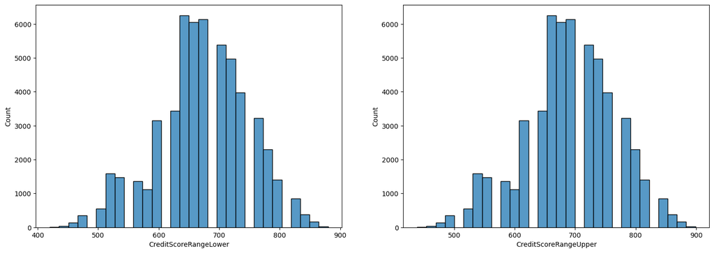

```python
# Distribution for credit score range lower and upper limit greater or equal to 400
plt.figure(figsize = [18,6])

plt.subplot(1,2,1)
sb.histplot(x='CreditScoreRangeLower', data=prosper_loan_sub[prosper_loan_sub.CreditScoreRangeLower>=400], bins=30, kde=False)
plt.subplot(1,2,2)
sb.histplot(x='CreditScoreRangeUpper', data=prosper_loan_sub[prosper_loan_sub.CreditScoreRangeUpper>=400], bins=30, kde=False);
```

Initially, the credit score range, with both lower and upper limits, seems to display a left-skewed pattern. However, upon closer examination, it becomes evident that only a few values fall below 400 and above, while the majority of the data is concentrated within a specific range. By replotting and considering only values greater than 400, both the upper and lower credit score limits exhibit a distribution resembling a normal distribution.

Given that both the upper and lower credit score ranges share a similar distribution of values, it would be more convenient to work with the average of these two columns. This approach allows for easier analysis and interpretation of the credit score information.

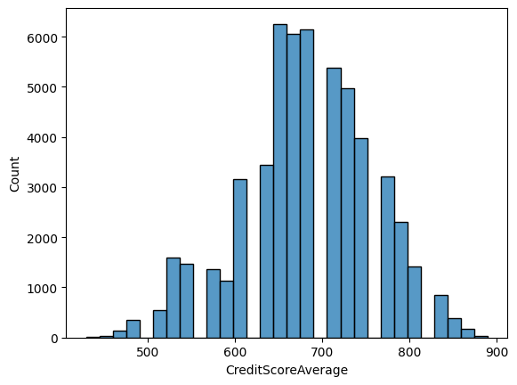

```python
prosper_loan_sub['CreditScoreAverage'] = (prosper_loan_sub.CreditScoreRangeLower + prosper_loan_sub.CreditScoreRangeUpper)/2
sb.histplot(x='CreditScoreAverage', data=prosper_loan_sub[prosper_loan_sub.CreditScoreAverage>=400], bins=30, kde=False)
```

#### IsBorrowerHomeowner

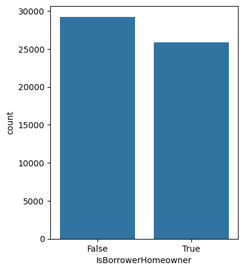

```python
plt.figure(figsize=(4, 5))
sb.countplot(x='IsBorrowerHomeowner', data=prosper_loan_sub, color=b_color);
```

The majority of loan recipients are non-homeowners.

#### CurrentlyInGroup

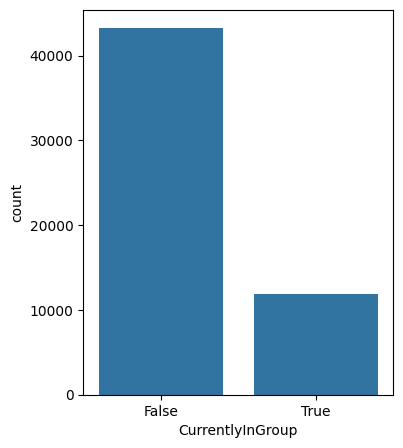

```python
plt.figure(figsize=(4, 5))
sb.countplot(x='CurrentlyInGroup', data=prosper_loan_sub, color=b_color);
```

The majority of loan recipients do not belong to any specific group.

#### Recommendations

```python
# Create a function to plot a histogram
def plot_histogram(data,x_column,bin_step=1,fig_size=(10,6),y_scale='log',y_ticks=None):
    bins = np.arange(0, data[x_column].max()+1,bin_step)
    plt.figure(figsize=fig_size)
    sb.histplot(x=x_column,data=data,bins=bins)
    plt.yscale(y_scale)
    if y_ticks is not None:
        plt.yticks(y_ticks,y_ticks)
    plt.show()
```

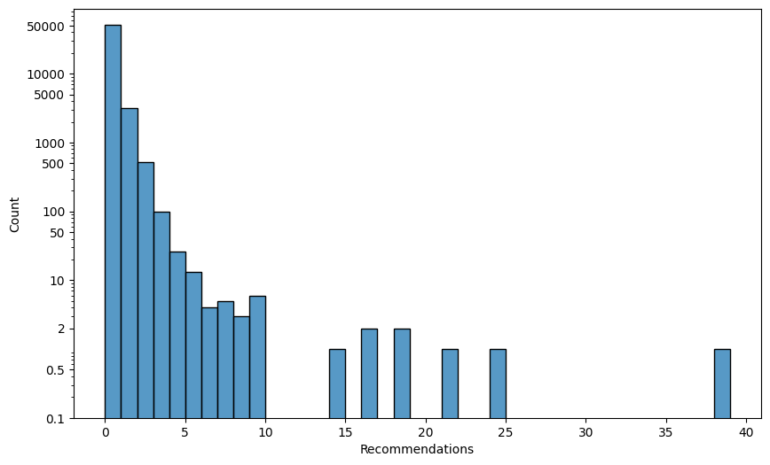

```python
yticks= [0.1, 0.5, 2, 10, 50, 100, 500, 1000, 5000, 10000, 50000]
plot_histogram(prosper_loan_sub,'Recommendations',y_ticks=yticks)
```

#### InvestmentFromFriendsCount

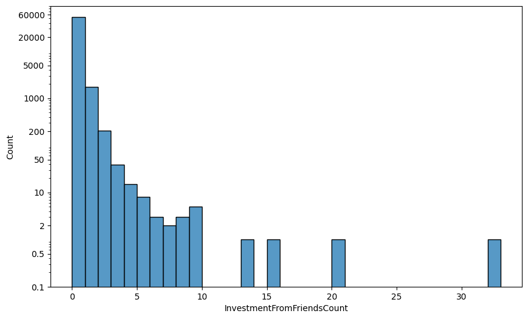

```python
yticks= [0.1, 0.5, 2, 10, 50, 200, 1000, 5000, 20000, 60000]
plot_histogram(prosper_loan_sub,'InvestmentFromFriendsCount',y_ticks=yticks)
```

The distribution of InvestmentFromFriendsCount appears to be right-skewed, with the majority of values falling below 10.

Furthermore, there seems to be a correlation between InvestmentFromFriendsCount and Recommendations, as both variables exhibit a similar distribution pattern.

#### LP_CustomerPrincipalPayments (Cummulative Principal Payments made on the loan before being charged off)

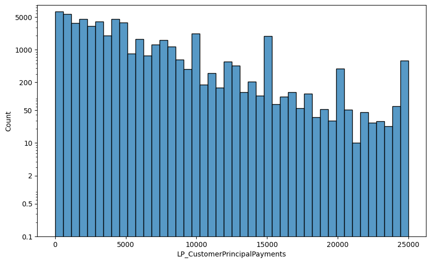

```python
bins = np.linspace(0, 25000, 45)
plt.figure(figsize=(10, 6));
sb.histplot(x='LP_CustomerPrincipalPayments', data=prosper_loan_sub, bins=bins)
plt.yscale('log')
yticks= [0.1, 0.5, 2, 10, 50, 200, 1000, 5000]
plt.yticks(yticks, yticks);
```

It appears that the number of payments made before being charged off decreases as the loan amount increases, with noticeable spikes occurring at regular intervals of 5000. This observation suggests a potential correlation between the loan amount and the frequency of payments before charge-off, where larger loan amounts tend to have fewer payments made before reaching the charged-off status, with intermittent spikes possibly indicating specific thresholds or decision points in the loan repayment process.

### Discuss the distribution(s) of your variable(s) of interest. Were there any unusual points? Did you need to perform any transformations?

The variable of interest in this exploration is categorical, and during the analysis, no unusual data points were observed. The only transformation performed on this variable was to select and consider only the values that are relevant to the specific purpose of the investigation. This focused approach allows for a more targeted and meaningful analysis of the categorical variable.

### Of the features you investigated, were there any unusual distributions? Did you perform any operations on the data to tidy, adjust, or change the form of the data? If so, why did you do this?

During the analysis, a few outlier points were observed in the lower and upper limits of the credit score range, recommendations, and investment from friends count. These outliers, however, were not removed from the dataset since they did not have any adverse impact on the data quality; instead, they were considered as exceptions to the common pattern.

Additionally, the listing category values were converted to strings based on the information obtained from the dataset documentation. This transformation was likely performed to facilitate better understanding and interpretation of the data.

Finally, to simplify the data representation, the credit score range's upper and lower values were combined into a single column named CreditScoreAverage by taking the average of the two column values. This consolidation allows for easier analysis and comparison while retaining the essential credit score information.

## Bivariate Exploration

#### Corrrelation of numeric variables

```python
numeric_vars= ['InvestmentFromFriendsCount', 'Recommendations', 'CreditScoreAverage', 'LP_CustomerPrincipalPayments']
cat_vars = ['ListingCategory', 'EmploymentStatus', 'IsBorrowerHomeowner', 'CurrentlyInGroup','IncomeVerifiable', 'LoanStatus']
```

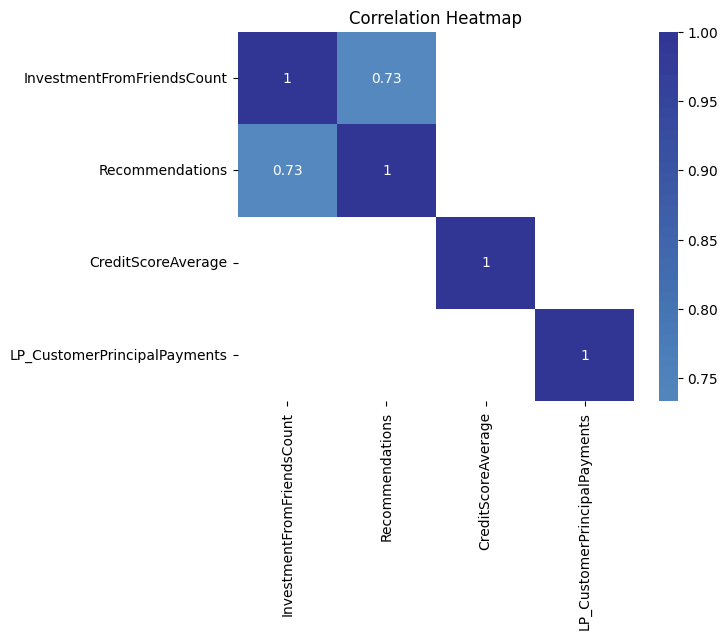

```python
sb.heatmap(data= prosper_loan_sub[numeric_vars].corr(), annot=True, cmap='RdYlBu', center=0, mask = prosper_loan_sub[numeric_vars].corr() <= 0.5);
plt.title('Correlation Heatmap')
plt.show()
```

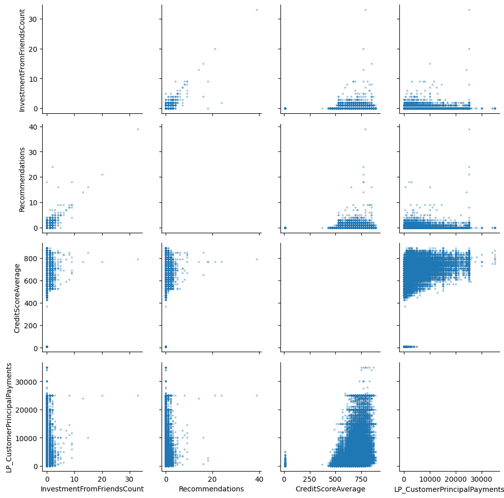

```python
g=sb.PairGrid(data=prosper_loan_sub, vars=numeric_vars)
g.map_offdiag(plt.scatter, s=4, alpha = 0.3);
```

As anticipated, there is a strong correlation between the count of Recommendations and InvestmentFromFriendsCount, indicating a relationship between these two variables. Moreover, there is a slight correlation between the average credit score and the number of principal payments made before being charged off, suggesting some level of association between these two aspects.

Furthermore, the analysis reveals that the majority of values for both Recommendations and InvestmentFromFriendsCount fall below 10, indicating that most cases involve a relatively small number of recommendations and investments from friends. However, there are a few instances where higher numbers of recommendations are observed, but these are relatively infrequent compared to the lower values.

#### Recommendations distribution per loan status

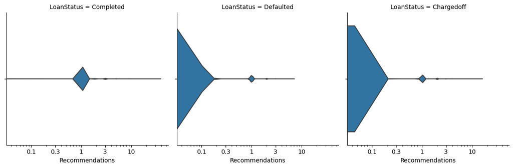

```python
g=sb.FacetGrid(data=prosper_loan_sub, col='LoanStatus', height=4)
g.map(sb.violinplot, 'Recommendations')
xticks = [0.1, 0.3, 1, 3, 10]
g.set(xscale='log', xticks=xticks, xticklabels=xticks);
```

#### Investment from friends distribution per loan status

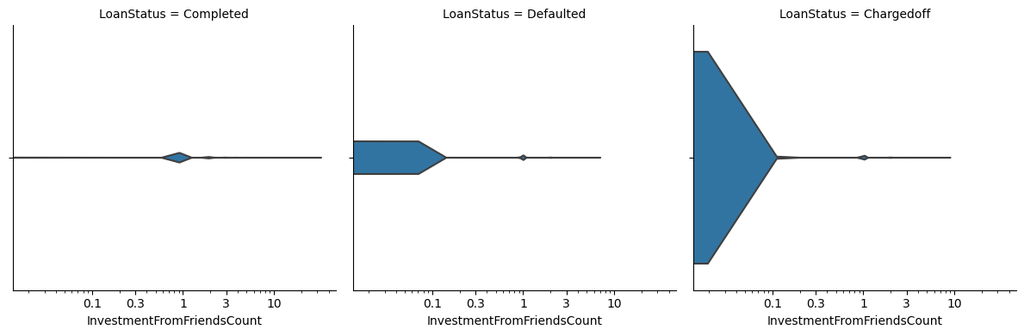

```python
g=sb.FacetGrid(data=prosper_loan_sub, col='LoanStatus', height=4)
g.map(sb.violinplot, 'InvestmentFromFriendsCount')
xticks = [0.1, 0.3, 1, 3, 10]
g.set(xscale='log', xticks=xticks, xticklabels=xticks);
```

This contrast depicted by the violin plot highlights the potential significance of social influence and support in determining loan success, as evidenced by the higher count of recommendations and investment from friends in completed loans compared to defaulted and charged-off lons.

#### Average credit score distribution per loan status

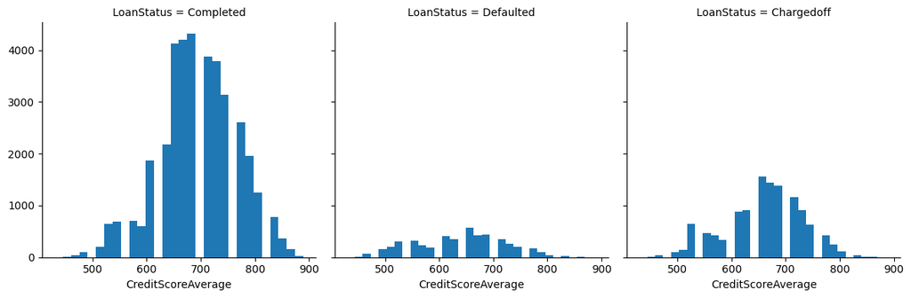

```python
g=sb.FacetGrid(data=prosper_loan_sub[prosper_loan_sub.CreditScoreAverage>=400], col='LoanStatus', height=4)
g.map(plt.hist, 'CreditScoreAverage', bins=30)
```

In the initial visualization, it is evident that a larger number of individuals with credit scores between 600 and 800 successfully completed their loans compared to those who defaulted.

Upon closer examination in the subsequent plot, it is apparent that the average credit score for completed loans is around 700, while defaulted and charged-off loans have average credit scores of approximately 650 and 680, respectively.

The more detailed plot further emphasizes that a significant proportion of individuals who completed their loans have average credit scores ranging from 650 to 750, indicating a relatively better creditworthiness. On the other hand, most of those who defaulted or were charged off have CreditScoreAverage below 700, suggesting a lower creditworthiness on average.

These observations suggest that a higher average credit score is associated with a higher likelihood of loan completion, while lower average credit scores are more common among defaulted and charged-off loans. The differences in average credit scores contribute to the varying rates of loan completion and default among borrowers.owers.

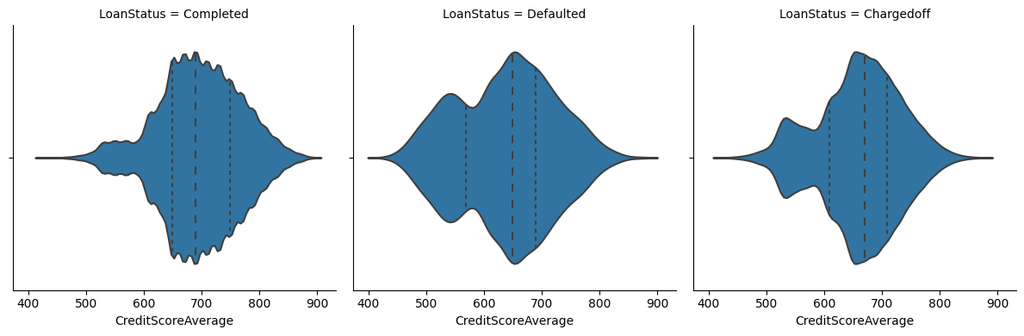

```python
g=sb.FacetGrid(data=prosper_loan_sub[prosper_loan_sub.CreditScoreAverage>=400], col='LoanStatus', height=4)
g.map(sb.violinplot, 'CreditScoreAverage', inner='quartile', bins=30)
```

#### Employent status distribution per loan status

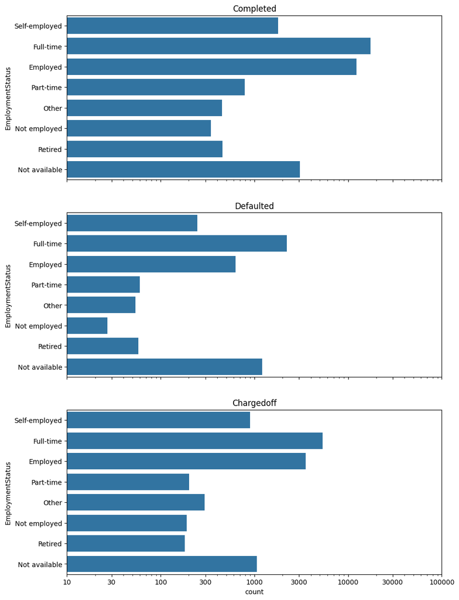

```python
fig, ax=plt.subplots(nrows=3, figsize=(10,15), sharex = True)
xticks=[10, 30, 100, 300, 1000, 3000, 10000, 30000, 100000]
y_order = ['Self-employed', 'Full-time', 'Employed', 'Part-time', 'Other', 'Not employed', 'Retired', 'Not available']

sb.countplot(data=prosper_loan_sub.query('LoanStatus=="Completed"'), y='EmploymentStatus', ax=ax[0], color=b_color, order=y_order)
ax[0].set_title('Completed')
ax[0].set_xlabel('')

sb.countplot(data=prosper_loan_sub.query('LoanStatus=="Defaulted"'), y='EmploymentStatus', ax=ax[1], color=b_color, order=y_order)
ax[1].set_title('Defaulted')
ax[1].set_xlabel('')

sb.countplot(data=prosper_loan_sub.query('LoanStatus=="Chargedoff"'), y='EmploymentStatus', ax=ax[2], color=b_color, order=y_order)
ax[2].set_title('Chargedoff')

plt.xscale('log')
plt.xticks(xticks,xticks);
```

#### Employment status and income verifiable

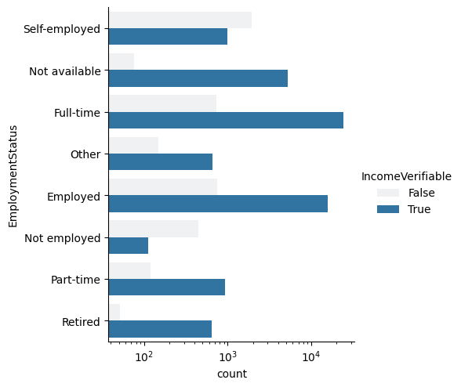

```python
g=sb.catplot(data=prosper_loan_sub, hue='IncomeVerifiable', y='EmploymentStatus', kind='count', orient='v',color=b_color)
g.set(xscale='log');
```

```python
prosper_loan_sub.groupby('EmploymentStatus')['LoanStatus'].value_counts()
```

```
EmploymentStatus  LoanStatus
Employed          Completed     12332
                  Chargedoff     3529
                  Defaulted       630
Full-time         Completed     17397
                  Chargedoff     5343
                  Defaulted      2217
Not available     Completed      3077
                  Defaulted      1204
                  Chargedoff     1065
Not employed      Completed       344
                  Chargedoff      190
                  Defaulted        27
Other             Completed       449
                  Chargedoff      295
                  Defaulted        54
Part-time         Completed       794
                  Chargedoff      202
                  Defaulted        60
Retired           Completed       459
                  Chargedoff      180
                  Defaulted        58
Self-employed     Completed      1783
                  Chargedoff      897
                  Defaulted       246
Name: count, dtype: int64
```

These findings imply that fully employed individuals are less likely to default on their loans compared to those who are not fully employed.

#### Loan status distribution per income verifiable

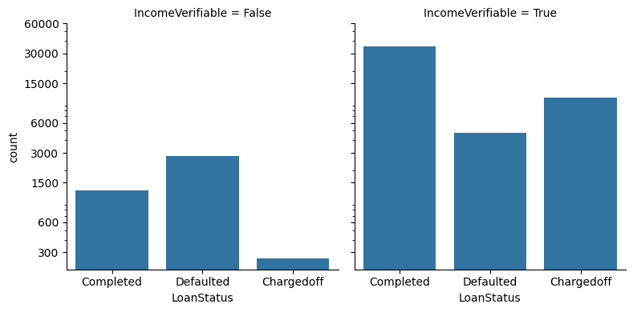

```python
g = sb.FacetGrid(data=prosper_loan_sub, col='IncomeVerifiable', height=4)
g.map(sb.countplot, 'LoanStatus')
g.set(yscale='log')
yticks=[300, 600, 1500, 3000, 6000, 15000, 30000, 60000]
g.set(yticks=yticks, yticklabels=yticks);
```

#### Listing Category distribution for each loan status

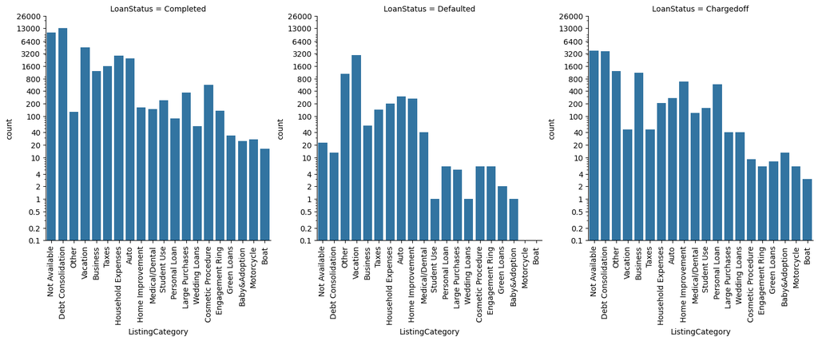

```python
order = prosper_loan_sub.ListingCategory.unique()
yticks =[0.1, 0.2, 0.5, 1, 2, 4, 10, 20, 40, 100, 200, 400, 800, 1600, 3200, 6400, 13000, 26000]
g=sb.FacetGrid(data=prosper_loan_sub, col='LoanStatus', height=5, sharey=False)
g.map(sb.countplot, 'ListingCategory')
g.set(yscale='log', yticks=yticks, yticklabels=yticks)
g.set_xticklabels(rotation=90)
```

```python
prosper_loan_sub.groupby('ListingCategory')['LoanStatus'].value_counts()
```

```
ListingCategory     LoanStatus
Auto                Completed      1210
                    Chargedoff      270
                    Defaulted        59
Baby&Adoption       Completed        27
                    Chargedoff       13
Boat                Completed        25
                    Chargedoff        3
Business            Completed      2848
                    Chargedoff     1108
                    Defaulted       301
Cosmetic Procedure  Completed        34
                    Chargedoff        9
                    Defaulted         1
Debt Consolidation  Completed     13167
                    Chargedoff     3655
                    Defaulted      1045
Engagement Ring     Completed        57
                    Chargedoff        6
Green Loans         Completed        10
                    Chargedoff        8
                    Defaulted         1
Home Improvement    Completed      2434
                    Chargedoff      669
                    Defaulted       141
Household Expenses  Completed       371
                    Chargedoff      203
                    Defaulted        23
Large Purchases     Completed       135
                    Chargedoff       41
                    Defaulted         5
Medical/Dental      Completed       239
                    Chargedoff      118
                    Defaulted        13
Motorcycle          Completed        86
                    Chargedoff        6
                    Defaulted         2
Not Available       Completed     10253
                    Chargedoff     3792
                    Defaulted      2903
Other               Completed      4551
                    Chargedoff     1225
                    Defaulted       266
Personal Loan       Completed      1620
                    Chargedoff      577
                    Defaulted       198
RV                  Completed        16
                    Defaulted         1
Student Use         Completed       561
                    Chargedoff      154
                    Defaulted        41
Taxes               Completed       160
                    Chargedoff       48
                    Defaulted         6
Vacation            Completed       145
                    Chargedoff       47
                    Defaulted         6
Wedding Loans       Completed       125
                    Chargedoff       40
                    Defaulted         6
Name: count, dtype: int64
```

Debt consolidation loans have the highest completion count (13,167) compared to the defaulted count (1,045) and the charged-off count (3,655).

The plot and value counts analysis above reveal the following relationships:

Business loans are more likely to be charged off.

#### Currently in Group vs Loan Status

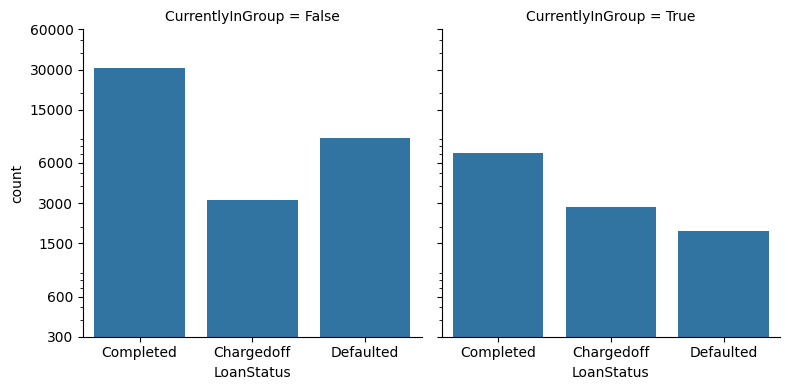

```python
order = prosper_loan_sub.LoanStatus.unique()
g = sb.FacetGrid(data=prosper_loan_sub, col='CurrentlyInGroup', height=4)
g.map(sb.countplot, 'LoanStatus')
g.set(yscale='log')
yticks=[300, 600, 1500, 3000, 6000, 15000, 30000, 60000]
g.set(yticks=yticks, yticklabels=yticks);
```

A larger number of individuals who do not belong to any specific group successfully completed their loans (30,000) compared to the completion count (6,000) of those who do belong to a group.

#### Is Borrower Homeowner

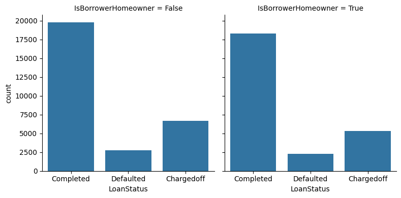

```python
g = sb.FacetGrid(data=prosper_loan_sub, col='IsBorrowerHomeowner', height=4)
g.map(sb.countplot, 'LoanStatus')
```

Based on the presented plot, there is no significant correlation between homeownership and the likelihood of a loan being completed, charged off, or defaulted. Homeownership does not appear to be a determining factor in the loan outcome.

#### LP_CustomerPrincipalPayments vs LoanStatus

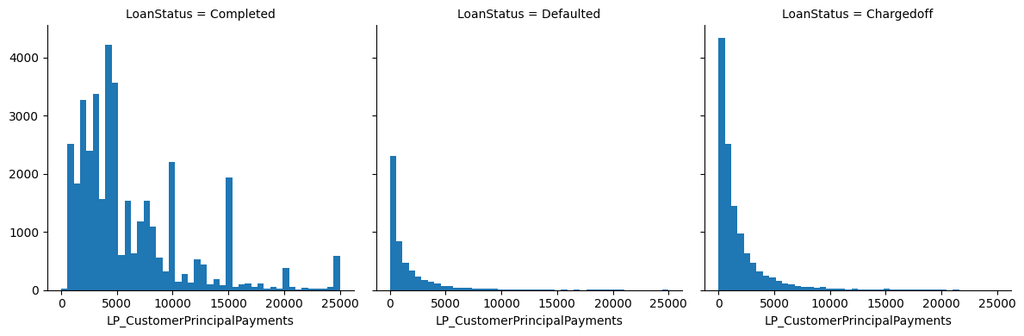

```python
bins = np.linspace(0, 25000, 45)
g=sb.FacetGrid(data=prosper_loan_sub, col='LoanStatus', height=4)
g.map(plt.hist, 'LP_CustomerPrincipalPayments', bins=bins)
```

Upon closer examination with the violin plot below, the following observations can be made:

For loans that have initially been charged off but were eventually completed, the principal payments predominantly fall between the range of 2000 and 5000.

On the other hand, loans that were never completed and ended up defaulted or charged off show principal payments primarily ranging from 0 to 1000.

These findings indicate that higher principal payments are associated with completed loans, and loans with lower principal payments have a higher likelihood of default or being charged off without completion.

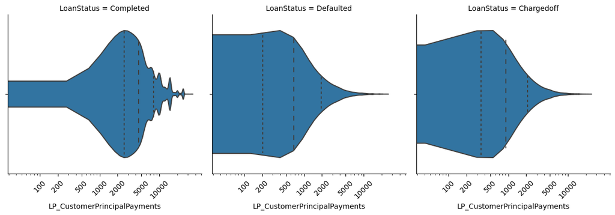

```python
xticks = [100, 200, 500, 1000, 2000, 5000, 10000]
g=sb.FacetGrid(data=prosper_loan_sub, col='LoanStatus', height=4)
g.map(sb.violinplot, 'LP_CustomerPrincipalPayments', bins=bins, inner='quartile')
g.set(xscale='log', xticks=xticks, xticklabels=xticks)
g.set_xticklabels(rotation=45);
```

#### Recommendations vs Investment from friends count

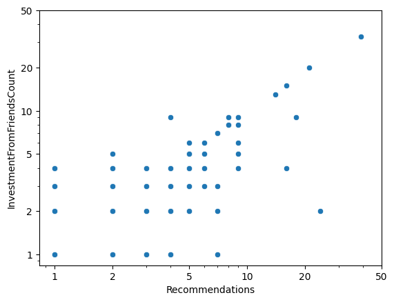

```python
sb.scatterplot(x='Recommendations', y='InvestmentFromFriendsCount', data=prosper_loan_sub)
ticks=[1, 2, 5, 10, 20, 50]
plt.xscale('log')
plt.yscale('log')
plt.xticks(ticks, ticks)
plt.yticks(ticks, ticks);
```

The data shows a positive relationship between the number of recommendations and the investment amount from friends for most loans in our dataset, aligning with the previously observed correlation of 0.73. However, there are a few exceptions to this trend.

#### Principal payment before charged off vs Average credit score

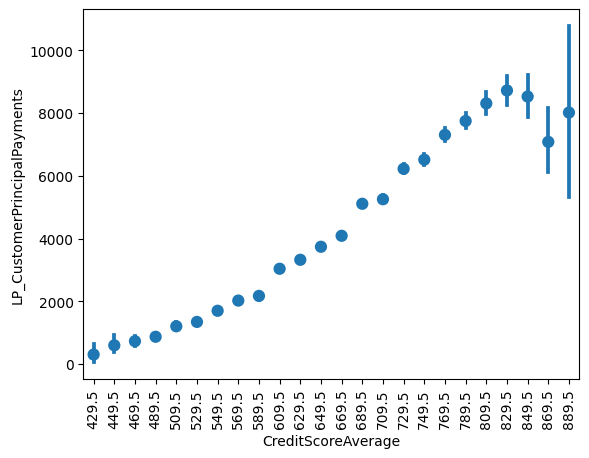

```python
sb.pointplot(y='LP_CustomerPrincipalPayments', x='CreditScoreAverage',
               data=prosper_loan_sub[prosper_loan_sub['CreditScoreAverage']>=400],
              join=False)
plt.xticks(rotation=90);
```

It appears that the average payment amount made before a loan is charged off tends to increase as the credit score average of borrowers increases.

### Talk about some of the relationships you observed in this part of the investigation. How did the feature(s) of interest vary with other features in the dataset?

These findings highlight the important factors that influence loan completion and default rates, as well as areas where specific features may have limited impact on loan outcomes.

## Multivariate Exploration

#### Employment status, average credit score and loan status

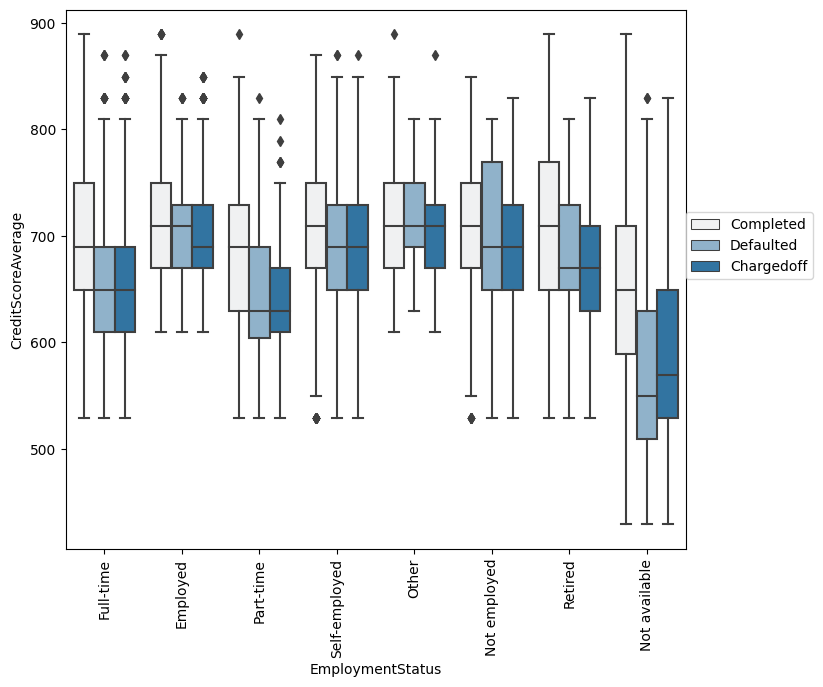

```python
y_order = ['Full-time', 'Employed', 'Part-time', 'Self-employed', 'Other', 'Not employed', 'Retired', 'Not available']
fig, ax=plt.subplots(nrows=1, figsize=(8, 7))
sb.boxplot(data=prosper_loan_sub.query('CreditScoreAverage>=400'), y='CreditScoreAverage',
           color=b_color, order=y_order, x='EmploymentStatus', ax=ax, hue='LoanStatus')
plt.legend(loc=(1, 0.5))
plt.xticks(rotation=90);
```

The presented plot further supports the previous observations that fully employed individuals tend to complete their loans successfully. However, it also highlights an interesting pattern: among those who are fully employed but end up defaulting, their average credit scores are lower compared to those who completed their loans.

Additionally, the plot indicates that individuals with the highest likelihood of defaulting are those who select 'Not available' as their employment status. Furthermore, most of these individuals have average credit scores below 650.

These findings suggest that employment status and credit scores are essential factors that influence loan completion and default rates. Fully employed individuals generally have better loan completion rates, but credit score plays a crucial role in differentiating between those who complete their loans and those who default, especially for those with 'Not available' employment sta tus.

#### Employment Status, Investment from friends count and loan status

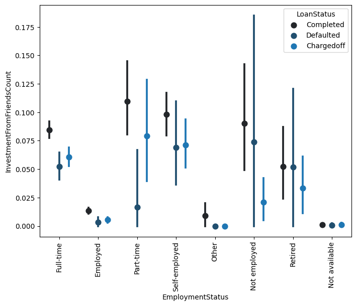

```python
fig, ax = plt.subplots(nrows=1, figsize=(8,6))
sb.pointplot(x='EmploymentStatus', y='InvestmentFromFriendsCount', data=prosper_loan_sub,
             hue='LoanStatus', ax=ax, join=False, dodge=0.5, order=y_order, color=b_color)
plt.xticks(rotation=90);
```